# Hybatelé 2015

### Joint Actor-Actor Mentions

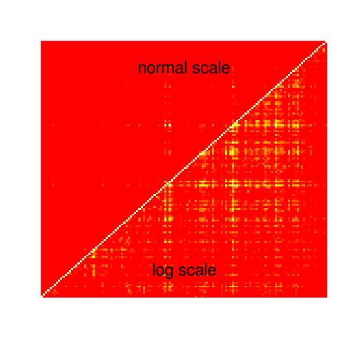

6831 out of 9800 actor pairs never co-mentioned.

### Joint Actor-Actor Mentions

[interactive chart not shown]

[interactive chart not shown]

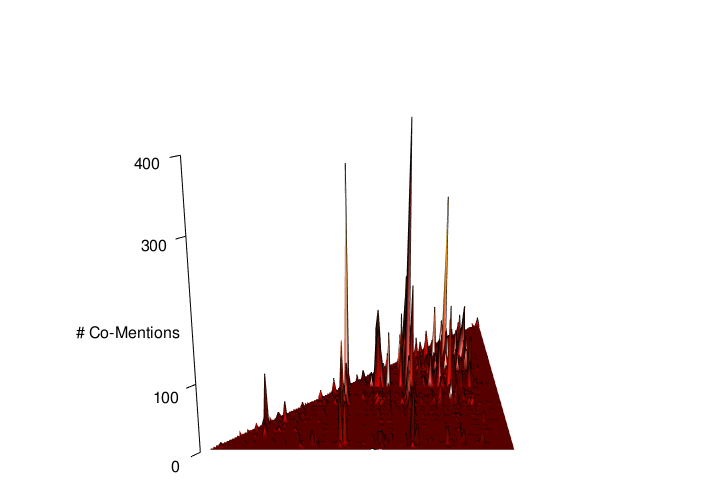

6831 out of 9800 actor pairs never co-mentioned.

### Co-Mention Counts

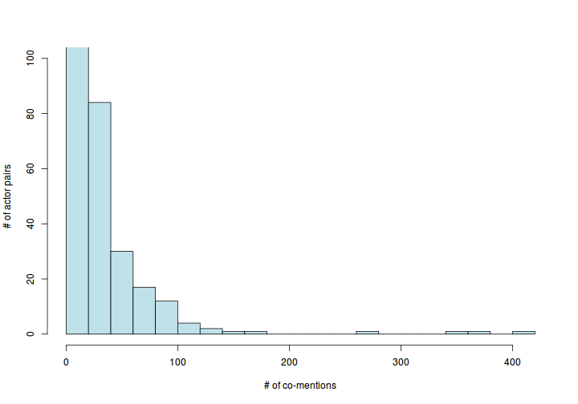

### Top Ten Co-Mentioned Pairs

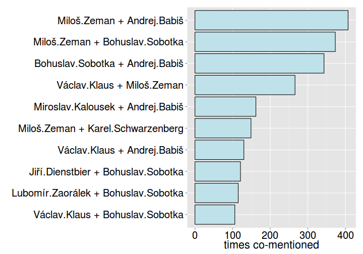

### Least/Most Co-Mentioned  
on Average

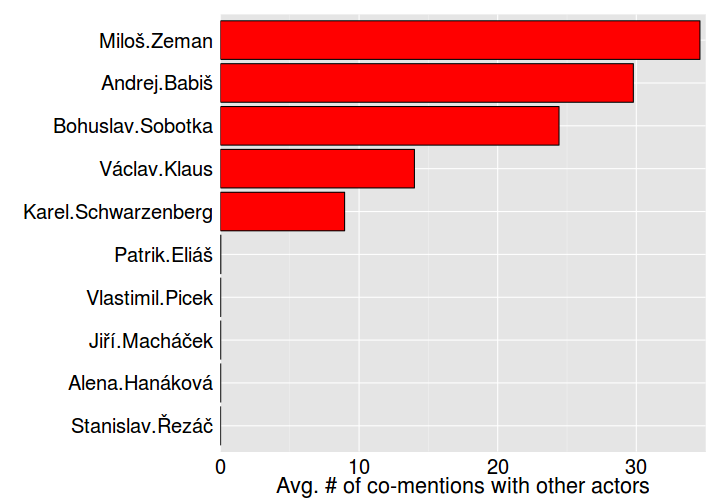

### Hierarchical clustering

in which similarity = number of co-mentions

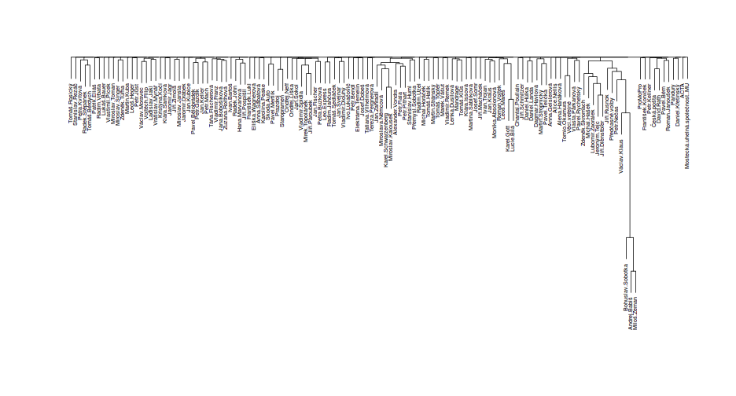

### Co-Mentioning Graph

Edge if at least 100 times co-mentioned

[figure not shown]

### Actor-Actor Similarity

- Co-mention rate is normalized by individual mention rates
  - \[ \frac{ab}{ \sqrt{ |a||b| }} \sim \frac{ \textrm{# of co-mentions}}{ \sqrt{ \textrm{# of } a\textrm{'s mentions} \times \textrm{# of } b\textrm{'s mentions} } } \\[10pt]\]
    - Known as **cosine similarity**

  ### Actor-Actor Similarity

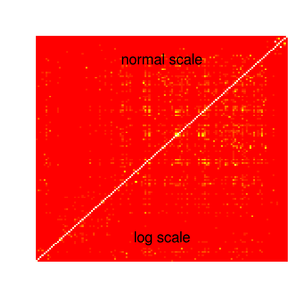

  ### Top Ten Similar Pairs

[figure not shown]

  ### Least/Most Similar to the Rest

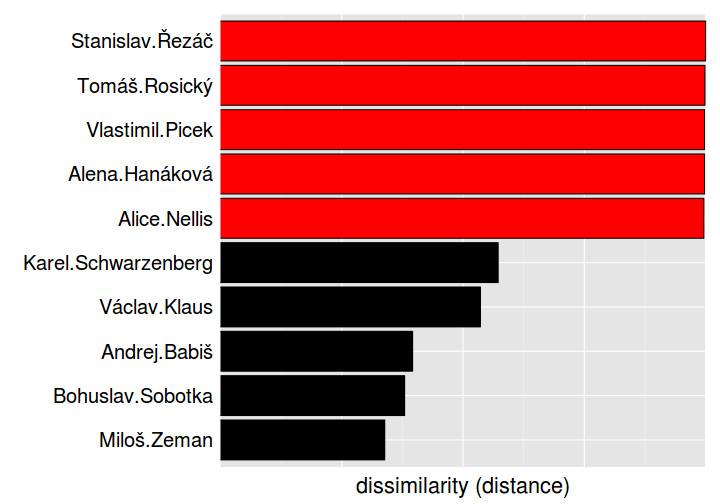

  ### Hierarchical clustering

  in which the **cosine similarity** is used

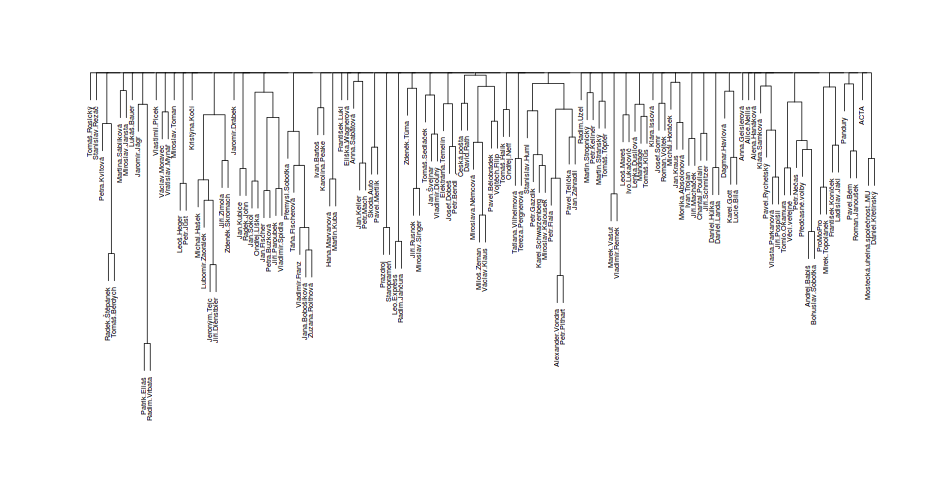

  ### Similarity Graph

[figure not shown]

  ### 2D Projection (MDS)

  similar are near each other

[figure not shown]

  ### Frequent Set Associations

  ```
  ##    items                 support
  ## 1  {Bohuslav.Sobotka,
  ##     Jeroným.Tejc,
  ##     Lubomír.Zaorálek,
  ##     Michal.Hašek}         0.0054
  ## 2  {Andrej.Babiš,
  ##     Bohuslav.Sobotka,
  ##     Jeroným.Tejc,
  ##     Michal.Hašek}         0.0058
  ## 3  {Bohuslav.Sobotka,
  ##     Jiří.Dienstbier,
  ##     Lubomír.Zaorálek,
  ##     Michal.Hašek}         0.0056
  ## 4  {Andrej.Babiš,
  ##     Bohuslav.Sobotka,
  ##     Jiří.Dienstbier,
  ##     Michal.Hašek}         0.0058
  ## 5  {Andrej.Babiš,
  ##     Bohuslav.Sobotka,
  ##     Michal.Hašek,
  ##     Miloš.Zeman}          0.0078
  ## 6  {Bohuslav.Sobotka,
  ##     Jeroným.Tejc,
  ##     Jiří.Dienstbier,
  ##     Zdeněk.Škromach}      0.0052
  ## 7  {Bohuslav.Sobotka,
  ##     Jeroným.Tejc,
  ##     Miloš.Zeman,
  ##     Zdeněk.Škromach}      0.0054
  ## 8  {Bohuslav.Sobotka,
  ##     Jeroným.Tejc,
  ##     Jiří.Dienstbier,
  ##     Jiří.Paroubek}        0.0052
  ## 9  {Andrej.Babiš,
  ##     Jeroným.Tejc,
  ##     Jiří.Dienstbier,
  ##     Lubomír.Zaorálek}     0.0052
  ## 10 {Andrej.Babiš,
  ##     Bohuslav.Sobotka,
  ##     Jeroným.Tejc,
  ```

  [output cut: 41 more lines]

  ```
  ## 21 {Bohuslav.Sobotka,
  ##     Jeroným.Tejc,
  ##     Jiří.Dienstbier,
  ##     Michal.Hašek,
  ##     Miloš.Zeman}          0.0056
  ## 22 {Bohuslav.Sobotka,
  ##     Jeroným.Tejc,
  ##     Jiří.Dienstbier,
  ##     Lubomír.Zaorálek,
  ##     Miloš.Zeman}          0.0050
  ## 23 {Andrej.Babiš,
  ##     Bohuslav.Sobotka,
  ##     Jeroným.Tejc,
  ##     Jiří.Dienstbier,
  ##     Miloš.Zeman}          0.0062
  ```

  ### Association Rules

  ```
  ##    lhs                      rhs                support confidence      lift
  ## 1  {Jan.Fischer}         => {Miloš.Zeman}       0.0072  0.8000000  3.311258
  ## 2  {Jeroným.Tejc}        => {Bohuslav.Sobotka}  0.0180  0.8333333  6.154604
  ## 3  {Jiří.Paroubek,
  ##     Vladimír.Špidla}     => {Bohuslav.Sobotka}  0.0056  0.9655172  7.130851
  ## 4  {Bohuslav.Sobotka,
  ##     Pavel.Bělobrádek}    => {Andrej.Babiš}      0.0080  0.8333333  4.125413
  ## 5  {Martin.Stropnický,
  ##     Bohuslav.Sobotka}    => {Andrej.Babiš}      0.0058  0.8285714  4.101839
  ## 6  {Jiří.Rusnok,
  ##     Václav.Klaus}        => {Miloš.Zeman}       0.0056  0.9333333  3.863135
  ## 7  {Jeroným.Tejc,
  ##     Michal.Hašek}        => {Jiří.Dienstbier}   0.0076  0.8085106 21.165200
  ## 8  {Jiří.Dienstbier,
  ##     Michal.Hašek}        => {Jeroným.Tejc}      0.0076  0.8260870 38.244767
  ## 9  {Jeroným.Tejc,
  ##     Michal.Hašek}        => {Bohuslav.Sobotka}  0.0094  1.0000000  7.385524
  ## 10 {Michal.Hašek,
  ##     Zdeněk.Škromach}     => {Bohuslav.Sobotka}  0.0060  0.9677419  7.147282
  ## 11 {Lubomír.Zaorálek,
  ##     Michal.Hašek}        => {Bohuslav.Sobotka}  0.0072  0.9729730  7.185916
  ## 12 {Jiří.Dienstbier,
  ##     Michal.Hašek}        => {Bohuslav.Sobotka}  0.0092  1.0000000  7.385524
  ## 13 {Andrej.Babiš,
  ##     Michal.Hašek}        => {Bohuslav.Sobotka}  0.0110  0.8208955  6.062744
  ## 14 {Michal.Hašek,
  ##     Miloš.Zeman}         => {Bohuslav.Sobotka}  0.0112  0.9333333  6.893156
  ## 15 {Jeroným.Tejc,
  ##     Zdeněk.Škromach}     => {Bohuslav.Sobotka}  0.0066  0.8918919  6.587089
  ## 16 {Jeroným.Tejc,
  ##     Zdeněk.Škromach}     => {Miloš.Zeman}       0.0060  0.8108108  3.356005
  ## 17 {Jeroným.Tejc,
  ##     Jiří.Paroubek}       => {Jiří.Dienstbier}   0.0054  0.9642857 25.243082
  ## 18 {Jiří.Dienstbier,
  ##     Jiří.Paroubek}       => {Jeroným.Tejc}      0.0054  0.8437500 39.062500
  ## 19 {Jeroným.Tejc,
  ##     Jiří.Paroubek}       => {Bohuslav.Sobotka}  0.0054  0.9642857  7.121756
  ## 20 {Jeroným.Tejc,
  ##     Lubomír.Zaorálek}    => {Jiří.Dienstbier}   0.0086  0.8600000 22.513089
  ## 21 {Jeroným.Tejc,
  ```

  [output cut: 160 more lines]

  ```
  ##     Jiří.Dienstbier,
  ##     Michal.Hašek,
  ##     Miloš.Zeman}         => {Jeroným.Tejc}      0.0056  0.8750000 40.509259
  ## 81 {Jeroným.Tejc,
  ##     Jiří.Dienstbier,
  ##     Lubomír.Zaorálek,
  ##     Miloš.Zeman}         => {Bohuslav.Sobotka}  0.0050  0.9259259  6.838448
  ## 82 {Bohuslav.Sobotka,
  ##     Jeroným.Tejc,
  ##     Lubomír.Zaorálek,
  ##     Miloš.Zeman}         => {Jiří.Dienstbier}   0.0050  0.8333333 21.815009
  ## 83 {Andrej.Babiš,
  ##     Jeroným.Tejc,
  ##     Jiří.Dienstbier,
  ##     Miloš.Zeman}         => {Bohuslav.Sobotka}  0.0062  0.9117647  6.733860
  ```

  Not causality (date ignored)!

  ### Frequent Association Sets of Sources

  ```
  ##    items                   support
  ## 1  {hn-ihned,
  ##     lidovky}             0.2045455
  ## 2  {ihned-dialog,
  ##     parlamentnilisty}    0.2045455
  ## 3  {parlamentnilisty,
  ##     prvnizpravy-dz}      0.2196970
  ## 4  {cn-zdomova,
  ##     ct24}                0.2045455
  ## 5  {echo24-dz,
  ##     hn-ihned}            0.2121212
  ## 6  {echo24-dz,
  ##     parlamentnilisty}    0.2121212
  ## 7  {krajskelisty,
  ##     parlamentnilisty}    0.2575758
  ## 8  {blog-idnes,
  ##     ihned-zpravy}        0.2045455
  ## 9  {ct24,
  ##     lidovky,
  ##     parlamentnilisty}    0.2045455
  ## 10 {lidovky,
  ##     mojenoviny-domaci,
  ##     parlamentnilisty}    0.2045455
  ## 11 {ihned-zdomova,
  ##     lidovky,
  ##     parlamentnilisty}    0.2121212
  ## 12 {hn-ihned,
  ##     ihned-dialog,
  ##     ihned-zdomova}       0.2045455
  ## 13 {parlamentnilisty,
  ##     parlamentnilisty-po,
  ##     svobodneforum}       0.2045455
  ## 14 {ihned-zdomova,
  ##     parlamentnilisty,
  ##     svobodneforum}       0.2045455
  ## 15 {hn-ihned,
  ##     parlamentnilisty,
  ##     svobodneforum}       0.2045455
  ## 16 {cn-zdomova,
  ##     ihned-zdomova,
  ```

  [output cut: 119 more lines]

  ```
  ## 50 {ct24,
  ##     hn-ihned,
  ##     ihned-zdomova,
  ##     mojenoviny-domaci,
  ##     parlamentnilisty}    0.2045455
  ## 51 {blog-idnes,
  ##     hn-ihned,
  ##     ihned-zdomova,
  ##     mojenoviny-domaci,
  ##     parlamentnilisty}    0.2045455
  ## 52 {hn-ihned,
  ##     ihned-zdomova,
  ##     mojenoviny-domaci,
  ##     parlamentnilisty,
  ##     parlamentnilisty-po} 0.2121212
  ```

  ### Association Rules on Sources

  ```
    ##     lhs                      rhs                     support confidence     lift
    ## 1   {lidovky}             => {ct24}                0.2121212  0.8484848 2.434783
    ## 2   {lidovky}             => {mojenoviny-domaci}   0.2045455  0.8181818 2.076923
    ## 3   {lidovky}             => {ihned-zdomova}       0.2121212  0.8484848 1.931034
    ## 4   {lidovky}             => {hn-ihned}            0.2045455  0.8181818 1.741935
    ## 5   {lidovky}             => {parlamentnilisty}    0.2424242  0.9696970 1.600000
    ## 6   {ihned-dialog}        => {ihned-zdomova}       0.2121212  0.9333333 2.124138
    ## 7   {ihned-dialog}        => {hn-ihned}            0.2121212  0.9333333 1.987097
    ## 8   {ihned-dialog}        => {parlamentnilisty}    0.2045455  0.9000000 1.485000
    ## 9   {prvnizpravy-dz}      => {parlamentnilisty}    0.2196970  0.9062500 1.495313
    ## 10  {svobodneforum}       => {parlamentnilisty}    0.2500000  0.9705882 1.601471
    ## 11  {cn-zdomova}          => {ct24}                0.2045455  0.8437500 2.421196
    ## 12  {cn-zdomova}          => {ihned-zdomova}       0.2045455  0.8437500 1.920259
    ## 13  {cn-zdomova}          => {parlamentnilisty}    0.2196970  0.9062500 1.495313
    ## 14  {denikreferendum-dz}  => {hn-ihned}            0.2424242  0.8888889 1.892473
    ## 15  {denikreferendum-dz}  => {parlamentnilisty}    0.2348485  0.8611111 1.420833
    ## 16  {echo24-dz}           => {hn-ihned}            0.2121212  0.8235294 1.753321
    ## 17  {echo24-dz}           => {parlamentnilisty}    0.2121212  0.8235294 1.358824
    ## 18  {eurozpravy-dz}       => {mojenoviny-domaci}   0.2196970  0.8529412 2.165158
    ## 19  {eurozpravy-dz}       => {ihned-zdomova}       0.2121212  0.8235294 1.874239
    ## 20  {eurozpravy-dz}       => {parlamentnilisty}    0.2500000  0.9705882 1.601471
    ## 21  {krajskelisty}        => {parlamentnilisty}    0.2575758  0.8717949 1.438462
    ## 22  {zpravy-blesk}        => {parlamentnilisty}    0.2727273  0.9230769 1.523077
    ## 23  {ihned-zpravy}        => {ihned-zdomova}       0.3030303  0.8888889 2.022989
    ## 24  {ihned-zpravy}        => {hn-ihned}            0.2954545  0.8666667 1.845161
    ## 25  {ihned-zpravy}        => {parlamentnilisty}    0.2803030  0.8222222 1.356667
    ## 26  {ct24}                => {parlamentnilisty}    0.3257576  0.9347826 1.542391
    ## 27  {parlamentnilisty-cl} => {parlamentnilisty-po} 0.2424242  0.8000000 2.246809
    ## 28  {parlamentnilisty-cl} => {ihned-zdomova}       0.2424242  0.8000000 1.820690
    ## 29  {parlamentnilisty-cl} => {hn-ihned}            0.2727273  0.9000000 1.916129
    ## 30  {parlamentnilisty-cl} => {parlamentnilisty}    0.2878788  0.9500000 1.567500
    ## 31  {blog-idnes}          => {ihned-zdomova}       0.2651515  0.8536585 1.942809
    ## 32  {blog-idnes}          => {hn-ihned}            0.2575758  0.8292683 1.765539
    ## 33  {blog-idnes}          => {parlamentnilisty}    0.2878788  0.9268293 1.529268
    ## 34  {mojenoviny-domaci}   => {parlamentnilisty}    0.3484848  0.8846154 1.459615
    ## 35  {parlamentnilisty-po} => {parlamentnilisty}    0.3484848  0.9787234 1.614894
    ## 36  {ihned-zdomova}       => {hn-ihned}            0.3636364  0.8275862 1.761958
    ## 37  {ihned-zdomova}       => {parlamentnilisty}    0.3636364  0.8275862 1.365517
    ## 38  {ct24,
    ##      lidovky}             => {parlamentnilisty}    0.2045455  0.9642857 1.591071
    ## 39  {lidovky,
    ##      parlamentnilisty}    => {ct24}                0.2045455  0.8437500 2.421196
    ## 40  {lidovky,
    ##      mojenoviny-domaci}   => {parlamentnilisty}    0.2045455  1.0000000 1.650000
    ## 41  {lidovky,
    ##      parlamentnilisty}    => {mojenoviny-domaci}   0.2045455  0.8437500 2.141827
    ## 42  {ihned-zdomova,
    ##      lidovky}             => {parlamentnilisty}    0.2121212  1.0000000 1.650000
    ## 43  {lidovky,
    ##      parlamentnilisty}    => {ihned-zdomova}       0.2121212  0.8750000 1.991379
    ## 44  {ihned-dialog,
    ##      ihned-zdomova}       => {hn-ihned}            0.2045455  0.9642857 2.052995
    ## 45  {hn-ihned,
    ##      ihned-dialog}        => {ihned-zdomova}       0.2045455  0.9642857 2.194581
    ## 46  {parlamentnilisty-po,
    ##      svobodneforum}       => {parlamentnilisty}    0.2045455  1.0000000 1.650000
    ## 47  {parlamentnilisty,
    ##      svobodneforum}       => {parlamentnilisty-po} 0.2045455  0.8181818 2.297872
    ## 48  {ihned-zdomova,
    ##      svobodneforum}       => {parlamentnilisty}    0.2045455  1.0000000 1.650000
    ## 49  {parlamentnilisty,
    ##      svobodneforum}       => {ihned-zdomova}       0.2045455  0.8181818 1.862069
    ## 50  {hn-ihned,
    ##      svobodneforum}       => {parlamentnilisty}    0.2045455  1.0000000 1.650000
    ## 51  {parlamentnilisty,
    ##      svobodneforum}       => {hn-ihned}            0.2045455  0.8181818 1.741935
    ## 52  {cn-zdomova,
    ##      ihned-zdomova}       => {parlamentnilisty}    0.2045455  1.0000000 1.650000
    ## 53  {cn-zdomova,
    ##      parlamentnilisty}    => {ihned-zdomova}       0.2045455  0.9310345 2.118906
    ## 54  {denikreferendum-dz,
    ##      mojenoviny-domaci}   => {hn-ihned}            0.2045455  0.9642857 2.052995
    ## 55  {denikreferendum-dz,
    ##      hn-ihned}            => {mojenoviny-domaci}   0.2045455  0.8437500 2.141827
    ## 56  {denikreferendum-dz,
    ##      mojenoviny-domaci}   => {parlamentnilisty}    0.2045455  0.9642857 1.591071
    ## 57  {denikreferendum-dz,
    ##      parlamentnilisty}    => {mojenoviny-domaci}   0.2045455  0.8709677 2.210918
    ## 58  {denikreferendum-dz,
    ##      parlamentnilisty-po} => {parlamentnilisty}    0.2045455  1.0000000 1.650000
    ## 59  {denikreferendum-dz,
    ##      parlamentnilisty}    => {parlamentnilisty-po} 0.2045455  0.8709677 2.446122
    ## 60  {denikreferendum-dz,
    ##      ihned-zdomova}       => {hn-ihned}            0.2121212  1.0000000 2.129032
    ## 61  {denikreferendum-dz,
    ##      hn-ihned}            => {ihned-zdomova}       0.2121212  0.8750000 1.991379
    ## 62  {denikreferendum-dz,
    ##      ihned-zdomova}       => {parlamentnilisty}    0.2045455  0.9642857 1.591071
    ## 63  {denikreferendum-dz,
    ##      parlamentnilisty}    => {ihned-zdomova}       0.2045455  0.8709677 1.982202
    ## 64  {denikreferendum-dz,
    ##      hn-ihned}            => {parlamentnilisty}    0.2196970  0.9062500 1.495313
    ## 65  {denikreferendum-dz,
    ##      parlamentnilisty}    => {hn-ihned}            0.2196970  0.9354839 1.991675
    ## 66  {ct24,
    ##      eurozpravy-dz}       => {parlamentnilisty}    0.2045455  1.0000000 1.650000
    ## 67  {eurozpravy-dz,
    ##      parlamentnilisty}    => {ct24}                0.2045455  0.8181818 2.347826
    ## 68  {blog-idnes,
    ##      eurozpravy-dz}       => {parlamentnilisty}    0.2045455  1.0000000 1.650000
    ## 69  {eurozpravy-dz,
    ##      parlamentnilisty}    => {blog-idnes}          0.2045455  0.8181818 2.634146
    ## 70  {eurozpravy-dz,
    ##      mojenoviny-domaci}   => {parlamentnilisty}    0.2121212  0.9655172 1.593103
    ## 71  {eurozpravy-dz,
    ##      parlamentnilisty}    => {mojenoviny-domaci}   0.2121212  0.8484848 2.153846
    ## 72  {eurozpravy-dz,
    ##      parlamentnilisty-po} => {parlamentnilisty}    0.2045455  1.0000000 1.650000
    ## 73  {eurozpravy-dz,
    ##      parlamentnilisty}    => {parlamentnilisty-po} 0.2045455  0.8181818 2.297872
    ## 74  {eurozpravy-dz,
    ##      ihned-zdomova}       => {parlamentnilisty}    0.2121212  1.0000000 1.650000
    ## 75  {eurozpravy-dz,
    ##      parlamentnilisty}    => {ihned-zdomova}       0.2121212  0.8484848 1.931034
    ## 76  {eurozpravy-dz,
    ##      hn-ihned}            => {parlamentnilisty}    0.2045455  1.0000000 1.650000
    ## 77  {eurozpravy-dz,
    ##      parlamentnilisty}    => {hn-ihned}            0.2045455  0.8181818 1.741935
    ## 78  {ct24,
    ##      zpravy-blesk}        => {ihned-zdomova}       0.2045455  0.9642857 2.194581
    ## 79  {ihned-zdomova,
    ##      zpravy-blesk}        => {ct24}                0.2045455  0.9000000 2.582609
    ## 80  {ct24,
    ##      zpravy-blesk}        => {parlamentnilisty}    0.2121212  1.0000000 1.650000
    ## 81  {blog-idnes,
    ##      zpravy-blesk}        => {parlamentnilisty}    0.2121212  1.0000000 1.650000
    ## 82  {mojenoviny-domaci,
    ##      zpravy-blesk}        => {parlamentnilisty}    0.2121212  0.9655172 1.593103
    ## 83  {parlamentnilisty-po,
    ##      zpravy-blesk}        => {parlamentnilisty}    0.2121212  0.9655172 1.593103
    ## 84  {ihned-zdomova,
    ##      zpravy-blesk}        => {parlamentnilisty}    0.2272727  1.0000000 1.650000
    ## 85  {parlamentnilisty,
    ##      zpravy-blesk}        => {ihned-zdomova}       0.2272727  0.8333333 1.896552
    ## 86  {hn-ihned,
    ##      zpravy-blesk}        => {parlamentnilisty}    0.2196970  1.0000000 1.650000
    ## 87  {parlamentnilisty,
    ##      zpravy-blesk}        => {hn-ihned}            0.2196970  0.8055556 1.715054
    ## 88  {ihned-zpravy,
    ##      mojenoviny-domaci}   => {ihned-zdomova}       0.2196970  1.0000000 2.275862
    ## 89  {ihned-zpravy,
    ##      mojenoviny-domaci}   => {hn-ihned}            0.2045455  0.9310345 1.982202
    ## 90  {ihned-zpravy,
    ##      mojenoviny-domaci}   => {parlamentnilisty}    0.2196970  1.0000000 1.650000
    ## 91  {ihned-zpravy,
    ##      parlamentnilisty-po} => {parlamentnilisty}    0.2121212  1.0000000 1.650000
    ## 92  {ihned-zdomova,
    ##      ihned-zpravy}        => {hn-ihned}            0.2803030  0.9250000 1.969355
    ## 93  {hn-ihned,
    ##      ihned-zpravy}        => {ihned-zdomova}       0.2803030  0.9487179 2.159151
    ## 94  {ihned-zdomova,
    ##      ihned-zpravy}        => {parlamentnilisty}    0.2575758  0.8500000 1.402500
    ## 95  {ihned-zpravy,
    ##      parlamentnilisty}    => {ihned-zdomova}       0.2575758  0.9189189 2.091333
    ## 96  {hn-ihned,
    ##      ihned-zpravy}        => {parlamentnilisty}    0.2424242  0.8205128 1.353846
    ## 97  {ihned-zpravy,
    ##      parlamentnilisty}    => {hn-ihned}            0.2424242  0.8648649 1.841325
    ## 98  {ct24,
    ##      parlamentnilisty-cl} => {parlamentnilisty-po} 0.2045455  0.9000000 2.527660
    ## 99  {parlamentnilisty-cl,
    ##      parlamentnilisty-po} => {ct24}                0.2045455  0.8437500 2.421196
    ## 100 {ct24,
    ##      parlamentnilisty-cl} => {ihned-zdomova}       0.2045455  0.9000000 2.048276
    ## 101 {ihned-zdomova,
    ##      parlamentnilisty-cl} => {ct24}                0.2045455  0.8437500 2.421196
    ## 102 {ct24,
    ##      parlamentnilisty-cl} => {hn-ihned}            0.2121212  0.9333333 1.987097
    ## 103 {ct24,
    ##      hn-ihned}            => {parlamentnilisty-cl} 0.2121212  0.8000000 2.640000
    ## 104 {ct24,
    ##      parlamentnilisty-cl} => {parlamentnilisty}    0.2272727  1.0000000 1.650000
    ## 105 {blog-idnes,
    ##      ct24}                => {ihned-zdomova}       0.2045455  1.0000000 2.275862
    ## 106 {blog-idnes,
    ##      ct24}                => {parlamentnilisty}    0.2045455  1.0000000 1.650000
    ## 107 {ct24,
    ##      mojenoviny-domaci}   => {parlamentnilisty-po} 0.2045455  0.8181818 2.297872
    ## 108 {ct24,
    ##      mojenoviny-domaci}   => {ihned-zdomova}       0.2272727  0.9090909 2.068966
    ## 109 {ct24,
    ##      ihned-zdomova}       => {mojenoviny-domaci}   0.2272727  0.8333333 2.115385
    ## 110 {ct24,
    ##      mojenoviny-domaci}   => {hn-ihned}            0.2196970  0.8787879 1.870968
    ## 111 {ct24,
    ##      hn-ihned}            => {mojenoviny-domaci}   0.2196970  0.8285714 2.103297
    ## 112 {ct24,
    ##      mojenoviny-domaci}   => {parlamentnilisty}    0.2500000  1.0000000 1.650000
    ## 113 {ct24,
    ##      parlamentnilisty-po} => {ihned-zdomova}       0.2348485  0.9117647 2.075051
    ## 114 {ct24,
    ##      ihned-zdomova}       => {parlamentnilisty-po} 0.2348485  0.8611111 2.418440
    ## 115 {ihned-zdomova,
    ##      parlamentnilisty-po} => {ct24}                0.2348485  0.8611111 2.471014
    ## 116 {ct24,
    ##      parlamentnilisty-po} => {hn-ihned}            0.2196970  0.8529412 1.815939
    ## 117 {ct24,
    ##      hn-ihned}            => {parlamentnilisty-po} 0.2196970  0.8285714 2.327052
    ## 118 {hn-ihned,
  ```